# Cryptocurrency arbitrage research

Maria Dmitrieva

High School of Economics

08 May 2020

Let’s rock.

```r
library(readxl)
library(vroom)
library(MASS)
library(tidyverse)
library(lubridate)
library(ggfortify)
library(RcppRoll)
library(ranger)
library(rpart)
library(zoo)
library(emh)
```

```r
# Loading KrakenUSD
KrakenUSD <- read_excel('Kraken(USD).xlsx',
    col_types = c('date', 'numeric', 'numeric',
        'numeric', 'numeric', 'numeric',
        'numeric', 'numeric'))

# Loading KrakenEUR
KrakenEUR <- read_excel('Kraken(EUR).xlsx',
    col_types = c('date', 'numeric', 'numeric',
        'numeric', 'numeric', 'numeric',
        'numeric', 'numeric'))

# Loading ZaifJPY
ZaifJPY <- read_excel("Zaif(JPY).xlsx",
    col_types = c("date", "numeric", "numeric",
        "numeric", "numeric", "numeric",
        "numeric", "numeric"))

# Loading EUR to USD exchange price history
eurusd_price_history <- vroom('eurusd_price-history.csv',
    ",", col_types = cols(`Change` = col_number(),
        `High` = col_number(), `Last` = col_number(),
        `Low` = col_number(), `Open` = col_number(),
        `Time` = col_datetime(format = '%m/%d/%Y'),
        `Volume` = col_number()))

# Loading JPY to USD exchange price history
jpyusd_price_history <- vroom("jpyusd_price-history.csv",
    ",", col_types = cols(`Change` = col_number(),
        `High` = col_number(), `Last` = col_number(),
        `Low` = col_number(), `Open` = col_number(),
        `Time` = col_datetime(format = "%m/%d/%Y"),
        `Volume` = col_number()))

# Loading comissions
commissions <- vroom('commissions.csv',
    ";", escape_double = FALSE, col_types = cols(dayCount = col_number(),
        maxDelay = col_number(), maxFee = col_number(),
        maxMinutes = col_number(), memCount = col_number(),
        minDelay = col_number(), minFee = col_number(),
        minMinutes = col_number()), trim_ws = TRUE)

# Loading S&P 500
GSPC <- vroom("^GSPC.csv", ",", col_types = cols(`Adj Close` = col_number(),
    Close = col_number(), Date = col_datetime(format = "%Y-%m-%d"),
    High = col_number(), Low = col_number(),
    Open = col_number(), Volume = col_number()))

# Loading Dow Jones Industrial Average
DJI <- vroom("^DJI.csv", ",", col_types = cols(`Adj Close` = col_number(),
    Close = col_number(), Date = col_datetime(format = "%Y-%m-%d"),
    High = col_number(), Low = col_number(),
    Open = col_number(), Volume = col_number()))

# Loading CBOE Volatility Index
VIX <- vroom("^VIX.csv", ",", col_types = cols(`Adj Close` = col_number(),
    Close = col_number(), Date = col_datetime(format = "%Y-%m-%d"),
    High = col_number(), Low = col_number(),
    Open = col_number(), Volume = col_number()))

# Loading hype data
Hype <- read_excel("multiTimeline.xlsx",
    col_names = c('Date', 'Hype'), skip = 1) %>% mutate(`Date` = as.POSIXct(`Date`, 'UTC'))
```

```r
# Calculating commissions
satonish <- 0.000001 #BTCS
avgBlock <- 127

KrakenUSD_commission <- as.numeric(satonish * KrakenUSD[360,'Close'] * avgBlock * commissions[8,'maxFee'])
ZaifJPY_commission <- as.numeric(satonish * ZaifJPY[360,'Close'] * avgBlock * (commissions[52,'maxFee'] + commissions[41,'maxFee']))
```

# 1 Arbitrage between two currencies in one exchange

Data from Kraken exchange in USD and EUR as well as EUR to USD exchange price is used.

## 1.1 Exchange validity test

Autocorrelation shows that price changes are gradual and consistent.

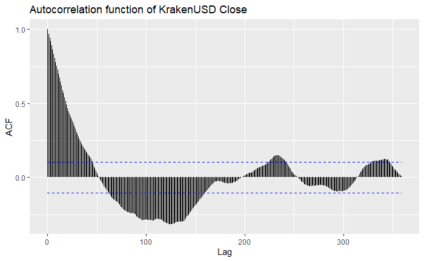

```r
# Autocorrelation function of KrakenUSD Close
autoplot(acf(KrakenUSD$`Close`, nrow(KrakenUSD), plot = FALSE)) +
  ggtitle('Autocorrelation function of KrakenUSD Close')
```

Whereas autocorrelation function of returns shows little correlation between them.

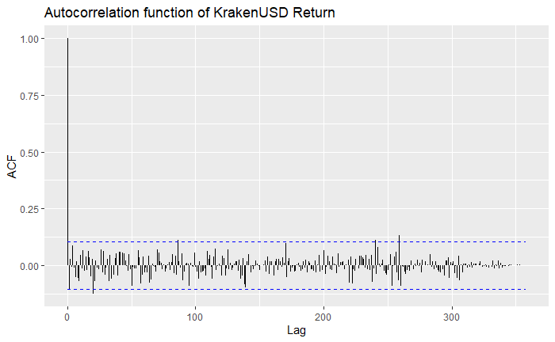

```r
# Autocorrelation function of KrakenUSD Return
autoplot(acf(KrakenUSD$`Close` - lag(KrakenUSD$`Close`),
             nrow(KrakenUSD), plot = FALSE, na.action = na.omit)) +
  ggtitle('Autocorrelation function of KrakenUSD Return')
```

Both findings speak for validity of the exchange processes.

## 1.2 Before commission

### 1.2.1 Calculations

Weighted Price EUR in USD is calculated as Weighted Price EUR converted to USD:
$$Weighted\ Price\ EUR\ in\ USD = Weighted\ Price\ EUR \cdot EUR\ to\ USD\ exchange\ rate$$

Arbitrage is calculated using this equation:
$$Arbitrage = |Weighted\ Price\ USD - Weighted\ Price\ EUR\ in\ USD|$$

Whereas percent arbitrage is calculated as arbitrage divided by the cheaper price:
$$Percent\ Arbitrage = \begin{cases} \frac{Arbitrage}{Weighted\ Price\ EUR\ in\ USD} & if\ Weighted\ Price\ USD > Weighted\ Price\ EUR\ in\ USD\\ \frac{Arbitrage}{Weighted\ Price\ USD} & if\ Weighted\ Price\ USD \leq Weighted\ Price\ EUR\ in\ USD\end{cases}$$

```r
# Filling hype
fill_skipped_hype <- function(x) {
  date <- ymd(x[1])
  dates <- as_datetime(seq(date - days(3), date + days(3), 'days'))
  hypes <- as.integer(rep(x[2], 7))
  tibble(Date = dates, Hype = hypes)
}
Hype_long <- do.call("bind_rows", apply(Hype, 1, fill_skipped_hype))

period <- 7

arbitrageUSDEUR <-

# Taking KrakenUSD data
select(KrakenUSD, `Timestamp`, `Weighted Price USD` = `Weighted Price`, `Close USD` = `Close`,
       `Open USD` = `Open`, `High USD` = `High`, `Low USD` = `Low`,
       `Volume USD` = `Volume (Currency)`, `Volume USD in BTC` = `Volume (BTC)`) %>%

# Joining KrakenEUR by timestamp
inner_join(
  select(KrakenEUR, `Timestamp`, `Weighted Price EUR` = `Weighted Price`, `Close EUR` = `Close`,
       `Open EUR` = `Open`, `High EUR` = `High`, `Low EUR` = `Low`,
       `Volume EUR` = `Volume (Currency)`, `Volume EUR in BTC` = `Volume (BTC)`),
  'Timestamp'
) %>%

# Joining EUR to USD exchange rates
left_join(
  select(eurusd_price_history, `Timestamp` = `Time`, `Close EUR to USD` = `Last`,
       `Open EUR to USD` = `Open`, `High EUR to USD` = `High`, `Low EUR to USD` = `Low`,
       `Volume EUR to USD` = `Volume`, `Return EUR to USD` = `Change`),
  'Timestamp'
) %>%

# Filling skipped EUR to USD prices with the last available
# Currency exchange prices are not calculated during weekends
fill(`Close EUR to USD`, `Open EUR to USD`, `High EUR to USD`, `Low EUR to USD`, `Volume EUR to USD`, `Return EUR to USD`) %>%

# Joining S&P 500
left_join(
  select(GSPC, `Timestamp` = `Date`, `Close GSPC` = `Close`,
       `Open GSPC` = `Open`, `High GSPC` = `High`, `Low GSPC` = `Low`,
       `Volume GSPC` = `Volume`),
  'Timestamp'
) %>%

# Filling weekends
fill(`Close GSPC`, `Open GSPC`, `High GSPC`, `Low GSPC`, `Volume GSPC`) %>%

# Joining Dow Jones Industrial Average
left_join(
  select(DJI, `Timestamp` = `Date`, `Close DJI` = `Close`,
       `Open DJI` = `Open`, `High DJI` = `High`, `Low DJI` = `Low`,
       `Volume DJI` = `Volume`),
  'Timestamp'
) %>%

# Filling weekends
fill(`Close DJI`, `Open DJI`, `High DJI`, `Low DJI`, `Volume DJI`) %>%

# Joining CBOE Volatility Index
left_join(
  select(VIX, `Timestamp` = `Date`, `Percent Close VIX` = `Close`, # VIX is a already counted in percent scale
       `Percent Open VIX` = `Open`, `Percent High VIX` = `High`, `Percent Low VIX` = `Low`),
  'Timestamp'
) %>%

# Filling weekends
fill(`Percent Close VIX`, `Percent Open VIX`, `Percent High VIX`, `Percent Low VIX`) %>%

# Joining hype
left_join(
  select(Hype_long, `Timestamp` = `Date`, `Percent Close Hype` = `Hype`), # Hype is a already counted in percent scale
  'Timestamp'
) %>%

# Calculating possible arbitrage
mutate(
  `Weighted Price EUR in USD` = round(`Weighted Price EUR` * `Close EUR to USD`, 2),
  `Arbitrage` = abs(`Weighted Price USD` - `Weighted Price EUR in USD`),
  `Percent Arbitrage` = if_else(`Weighted Price USD` > `Weighted Price EUR in USD`, # If price in USD is bigger
                                `Arbitrage` / `Weighted Price EUR in USD`,          # We buy for EUR and sell in USD
                                `Arbitrage` / `Weighted Price USD`),                # Else we but in USD and sell in EU
  `USD EUR in USD price ratio` = `Weighted Price USD` / `Weighted Price EUR in USD`,
  `Commission` = KrakenUSD_commission,
  `Commissioned Arbitrage` = `Arbitrage` - `Commission`,
  `Commissioned Arbitrage` = if_else(`Commissioned Arbitrage` < 0, 0, `Commissioned Arbitrage`),
  `Commissioned Percent Arbitrage` = if_else(`Weighted Price USD` > `Weighted Price EUR in USD`,
                                `Commissioned Arbitrage` / `Weighted Price EUR in USD`,
                                `Commissioned Arbitrage` / `Weighted Price USD`),
  # For arbitrage forecast
  `Close EUR in USD` = round(`Close EUR` * `Close EUR to USD`, 2),
  `Volume EUR in USD` = round(`Volume EUR` * `Close EUR to USD`, 2),
  `Return USD` = `Close USD` - lag(`Close USD`),
  #`Return EUR` = `Close EUR` - lag(`Close EUR`),
  `Return EUR in USD` = `Close EUR in USD` - lag(`Close EUR in USD`),
  `Return EUR to USD` = `Close EUR to USD` - lag(`Close EUR to USD`),
  `Absolute Return EUR to USD` = abs(`Return EUR to USD`), # Absolute change in currency rates intuitively seems to cause arbitrage
  `Return GSPC` = `Close GSPC` - lag(`Close GSPC`),
  `Return DJI` = `Close DJI` - lag(`Close DJI`),
  `Percent Return USD` = `Return USD` / lag(`Close USD`),
  #`Percent Return EUR` = `Return EUR` / lag(`Close EUR`),
  `Percent Return EUR in USD` = `Return EUR in USD` / lag(`Close EUR in USD`),
  `Percent Return EUR to USD` = `Return EUR to USD` / lag(`Close EUR to USD`),
  `Percent Absolute Return EUR to USD` = `Absolute Return EUR to USD` / lag(`Close EUR to USD`),
  `Percent Return GSPC` = `Return GSPC` / lag(`Close GSPC`),
  `Percent Return DJI` = `Return DJI` / lag(`Close DJI`),
  `Percent Return VIX` = `Percent Close VIX` - lag(`Percent Close VIX`),
  `Percent Return Hype` = `Percent Close Hype` - lag(`Percent Close Hype`),
  `SD Percent Return USD` = roll_sd(`Percent Return USD`, period, fill = NA, align = 'right'),
  #`SD Percent Return EUR` = roll_sd(`Percent Return EUR`, period, fill = NA, align = 'right'),
  `SD Percent Return EUR in USD` = roll_sd(`Percent Return EUR in USD`, period, fill = NA, align = 'right'),
  `SD Percent Return EUR to USD` = roll_sd(`Percent Return EUR to USD`, period, fill = NA, align = 'right'),
  `SD Percent Absolute Return EUR to USD` = roll_sd(`Percent Absolute Return EUR to USD`, period, fill = NA, align = 'right'),
  `SD Percent Return GSPC` = roll_sd(`Percent Return GSPC`, period, fill = NA, align = 'right'),
  `SD Percent Return DJI` = roll_sd(`Percent Return DJI`, period, fill = NA, align = 'right'),
  `SD Percent Return VIX` = roll_sd(`Percent Return VIX`, period, fill = NA, align = 'right'),
  `SD Percent Return Hype` = roll_sd(`Percent Return Hype`, period, fill = NA, align = 'right'),
  `Volume Change USD` = `Volume USD` - lag(`Volume USD`),
  #`Volume Change EUR` = `Volume EUR` - lag(`Volume EUR`),
  `Volume Change EUR in USD` = `Volume EUR in USD` - lag(`Volume EUR in USD`),
  `Volume Change EUR to USD` = `Volume EUR to USD` - lag(`Volume EUR to USD`),
  `Volume Change GSPC` = `Volume GSPC` - lag(`Volume GSPC`),
  `Volume Change DJI` = `Volume DJI` - lag(`Volume DJI`),
  `Percent Volume Change USD` = `Volume Change USD` / lag(`Volume USD`),
  #`Percent Volume Change EUR` = `Volume Change EUR` / lag(`Volume EUR`),
  `Percent Volume Change EUR in USD` = `Volume Change EUR in USD` / lag(`Volume EUR in USD`),
  `Percent Volume Change EUR to USD` = `Volume Change EUR to USD` / lag(`Volume EUR to USD`),
  `Percent Volume Change GSPC` = `Volume Change GSPC` / lag(`Volume GSPC`),
  `Percent Volume Change DJI` = `Volume Change DJI` / lag(`Volume DJI`),
  `SD Percent Volume Change USD` = roll_sd(`Percent Volume Change USD`, period, fill = NA, align = 'right'),
  #`SD Percent Volume Change EUR` = roll_sd(`Percent Volume Change EUR`, period, fill = NA, align = 'right'),
  `SD Percent Volume Change EUR in USD` = roll_sd(`Percent Volume Change EUR in USD`, period, fill = NA, align = 'right'),
  `SD Percent Volume Change EUR to USD` = roll_sd(`Percent Volume Change EUR to USD`, period, fill = NA, align = 'right'),
  `SD Percent Volume Change GSPC` = roll_sd(`Percent Volume Change GSPC`, period, fill = NA, align = 'right'),
  `SD Percent Volume Change DJI` = roll_sd(`Percent Volume Change DJI`, period, fill = NA, align = 'right'),
  `Future Arbitrage` = lead(`Arbitrage`),
  `Future Percent Arbitrage` = lead(`Percent Arbitrage`),
  `Future Arbitrage SD` = lead(roll_sd(`Arbitrage`, period, fill = NA, align = 'left')),
  `Future Percent Arbitrage SD` = lead(roll_sd(`Percent Arbitrage`, period, fill = NA, align = 'left')),
  `Future USD EUR in USD price ratio` = lead(`USD EUR in USD price ratio`),
  `Future Percent Return USD` = lead(`Percent Return USD`)
)

# Sanity check
if (arbitrageUSDEUR$`SD Percent Return USD`[1 + period] != sd(arbitrageUSDEUR$`Percent Return USD`[2:(1 + period)])) {
  stop('SD Percent Return USD is calculated incorrectly.')
}

# Printing
arbitrageUSDEUR %>%
select(
  `Timestamp`,
  `Weighted Price USD`,
  `Weighted Price EUR in USD`,
  `Arbitrage`,
  `Percent Arbitrage`
)
```

| Timestamp | Weighted Price USD | Weighted Price EUR in USD | Arbitrage | Percent Arbitrage |
| --- | --- | --- | --- | --- |
| 2019-04-02 | 4719.87 | 4725.43 | 5.56 | 1.177999e-03 |
| 2019-04-03 | 5064.60 | 5055.82 | 8.78 | 1.736612e-03 |
| 2019-04-04 | 4958.87 | 4952.22 | 6.65 | 1.342832e-03 |
| 2019-04-05 | 4994.67 | 4991.44 | 3.23 | 6.471078e-04 |
| 2019-04-06 | 5075.29 | 5076.51 | 1.22 | 2.403804e-04 |
| 2019-04-07 | 5151.00 | 5153.14 | 2.14 | 4.154533e-04 |
| 2019-04-08 | 5240.11 | 5248.17 | 8.06 | 1.538136e-03 |
| 2019-04-09 | 5213.22 | 5219.10 | 5.88 | 1.127902e-03 |
| 2019-04-10 | 5305.29 | 5310.11 | 4.82 | 9.085271e-04 |
| 2019-04-11 | 5113.31 | 5105.78 | 7.53 | 1.474799e-03 |

[output cut: 350 more lines]

### 1.2.2 Distribution

Percent arbitrage histogram has a steep curve and a long tail to the right.

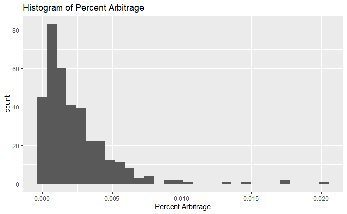

```r
ggplot(arbitrageUSDEUR, aes(`Percent Arbitrage`)) + geom_histogram(bins = 30) +
  ggtitle('Histogram of Percent Arbitrage')
```

- Mean percent arbitrage is low: 0.2408746%.
- 97.5% of observations have arbitrage within 0.8800188%.
- Only 7 records (1.9444444% of observations`) have arbitrage > 1%.

```r
arbitrageUSDEUR %>%
filter(`Percent Arbitrage` > 0.01) %>%
select(
  `Timestamp`,
  `Weighted Price USD`,
  `Weighted Price EUR in USD`,
  `Arbitrage`,
  `Percent Arbitrage`
)
```

| Timestamp | Weighted Price USD | Weighted Price EUR in USD | Arbitrage | Percent Arbitrage |
| --- | --- | --- | --- | --- |
| 2019-04-25 | 5259.05 | 5350.98 | 91.93 | 0.01748034 |
| 2019-06-27 | 11581.10 | 11383.39 | 197.71 | 0.01736829 |
| 2019-09-02 | 10139.39 | 10038.16 | 101.23 | 0.01008452 |
| 2019-09-24 | 8831.65 | 8947.94 | 116.29 | 0.01316741 |
| 2019-10-25 | 8222.28 | 8102.71 | 119.57 | 0.01475679 |
| 2020-03-13 | 5144.95 | 5248.78 | 103.83 | 0.02018095 |
| 2020-03-20 | 6361.02 | 6427.71 | 66.69 | 0.01048417 |

### 1.2.3 Nature of prices relationship

Weighted Price USD and Weighted Price EUR in USD have a strong linear relationship.

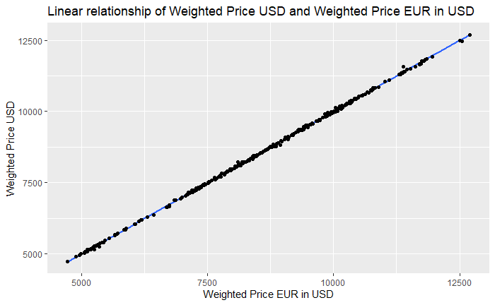

```r
ggplot(arbitrageUSDEUR, aes(`Weighted Price EUR in USD`, `Weighted Price USD`)) +
  geom_smooth(formula = y ~ x, method = 'lm') +
  geom_point() +
  ggtitle('Linear relationship of Weighted Price USD and Weighted Price EUR in USD')
```

```r
KrakenUSDEUR_lm <- lm(`Weighted Price USD` ~ `Weighted Price EUR in USD`, arbitrageUSDEUR)
summary(KrakenUSDEUR_lm)
```

```
Call:
lm(formula = `Weighted Price USD` ~ `Weighted Price EUR in USD`,
    data = arbitrageUSDEUR)

Residuals:
     Min       1Q   Median       3Q      Max
-111.737  -13.514   -0.558   12.133  200.108

Coefficients:
                              Estimate Std. Error  t value Pr(>|t|)
(Intercept)                 -1.247e+01  7.596e+00   -1.642    0.101
`Weighted Price EUR in USD`  1.001e+00  8.742e-04 1144.935   <2e-16 ***
---
Signif. codes:  0 ‘***’ 0.001 ‘**’ 0.01 ‘*’ 0.05 ‘.’ 0.1 ‘ ’ 1

Residual standard error: 29.35 on 358 degrees of freedom
Multiple R-squared:  0.9997,    Adjusted R-squared:  0.9997
F-statistic: 1.311e+06 on 1 and 358 DF,  p-value: < 2.2e-16
```

R-squared of 0.999727 speaks of a practically ideal linear relationship and that the exchange rates are set correctly.

Mean percent residuals are close to mean percent arbitrage and support the conclusion that arbitrage is low: 0.0023087 $\approx$ 0.0024087.

## 1.3 Arbitrage forecast

### 1.3.1 Correlations

Pearson’s correlation tables do not show any particularly strong connections. However we can observe some limited correlation with volume while somewhat weaker correlation is present with a set of other different predictors. This signifies of possible partial interactive dependencies.

```r
arbitrageUSDEUR_corr <-
rownames_to_column(as.data.frame(cor(na.omit(arbitrageUSDEUR[,-1]))), 'Correlates with') %>%
select(c(`Correlates with`, starts_with('Future'))) %>%
filter(!str_detect(`Correlates with`, 'Future|Commission'))
```

#### 1.3.1.1 Tables

##### 1.3.1.1.1 Future Arbitrage

```r
arbitrageUSDEUR_corr %>% arrange(desc(abs(`Future Arbitrage`))) %>% select(`Correlates with`, `Future Arbitrage`)
```

| Correlates with | Future Arbitrage |
| --- | --- |
| Volume EUR in USD | 0.3524548307 |
| Volume EUR | 0.3522255644 |
| Volume USD | 0.3075623039 |
| Volume EUR in BTC | 0.2745544031 |
| Volume Change EUR in USD | 0.2353396269 |
| Volume USD in BTC | 0.2275369450 |
| Volume Change USD | 0.2223963251 |
| Percent Close Hype | 0.1838134010 |
| High USD | 0.1736548934 |
| High EUR | 0.1712247787 |

[output cut: 67 more lines]

##### 1.3.1.1.2 Future Percent Arbitrage

```r
arbitrageUSDEUR_corr %>% arrange(desc(abs(`Future Percent Arbitrage`))) %>%
  select(`Correlates with`, `Future Percent Arbitrage`) %>%
  filter(str_detect(`Correlates with`, 'Percent'))
```

| Correlates with | Future Percent Arbitrage |
| --- | --- |
| Percent Return EUR to USD | -0.202224207 |
| Percent Volume Change EUR in USD | 0.188227258 |
| Percent Return EUR in USD | -0.163232341 |
| Percent Volume Change USD | 0.158610921 |
| Percent Return USD | -0.157691082 |
| Percent Close VIX | 0.146827533 |
| Percent Low VIX | 0.142389302 |
| Percent Open VIX | 0.135823316 |
| SD Percent Return EUR to USD | 0.134253124 |
| Percent High VIX | 0.124892664 |

[output cut: 22 more lines]

##### 1.3.1.1.3 Future Arbitrage SD

```r
arbitrageUSDEUR_corr %>% arrange(desc(abs(`Future Arbitrage SD`))) %>% select(`Correlates with`, `Future Arbitrage SD`)
```

| Correlates with | Future Arbitrage SD |
| --- | --- |
| Percent Close Hype | 0.542660729 |
| SD Percent Absolute Return EUR to USD | 0.306266825 |
| High USD | 0.306010075 |
| Weighted Price EUR in USD | 0.299696622 |
| Weighted Price USD | 0.298823450 |
| Close USD | 0.297986255 |
| High EUR | 0.297580645 |
| Close EUR in USD | 0.295936857 |
| SD Percent Return Hype | 0.292560461 |
| SD Percent Return EUR to USD | 0.290624773 |

[output cut: 67 more lines]

##### 1.3.1.1.4 Future Percent Arbitrage SD

```r
arbitrageUSDEUR_corr %>% arrange(desc(abs(`Future Percent Arbitrage SD`))) %>%
  select(`Correlates with`, `Future Percent Arbitrage SD`) %>%
  filter(str_detect(`Correlates with`, 'Percent'))
```

| Correlates with | Future Percent Arbitrage SD |
| --- | --- |
| Percent Close Hype | 0.43645585 |
| SD Percent Return EUR to USD | 0.43029906 |
| SD Percent Absolute Return EUR to USD | 0.41888418 |
| Percent Low VIX | 0.35967663 |
| Percent High VIX | 0.35766954 |
| Percent Close VIX | 0.35675254 |
| Percent Open VIX | 0.35545252 |
| SD Percent Return DJI | 0.30014538 |
| SD Percent Return GSPC | 0.28449112 |
| SD Percent Return Hype | 0.28441111 |

[output cut: 22 more lines]

### 1.3.2 Modelling

```r
arbitrageUSDEUR_nona <- na.omit(arbitrageUSDEUR) %>% select(-c(starts_with('Commission')))
X <- arbitrageUSDEUR_nona %>% select(starts_with('Percent'), starts_with('SD'), -c(`Timestamp`, starts_with('Future')))
y <- arbitrageUSDEUR_nona %>% select(`Future Percent Arbitrage`)
```

An ordinary least squares linear model is fitted using all available predictors to predict percent arbitrage during the next day.

```r
arbitrageUSDEUR_forc <- lm(as_vector(y) ~ ., X)
summary(arbitrageUSDEUR_forc)
```

```
Call:
lm(formula = as_vector(y) ~ ., data = X)

Residuals:
      Min        1Q    Median        3Q       Max
-0.004821 -0.001457 -0.000521  0.001168  0.013575

Coefficients:
                                          Estimate Std. Error t value Pr(>|t|)
(Intercept)                             -1.055e-03  9.838e-04  -1.072  0.28439
`Percent Close VIX`                      3.786e-04  1.824e-04   2.076  0.03874 *
`Percent Open VIX`                       1.471e-04  1.814e-04   0.811  0.41787
`Percent High VIX`                      -2.875e-04  1.386e-04  -2.074  0.03889 *
`Percent Low VIX`                       -2.865e-05  2.294e-04  -0.125  0.90070
`Percent Close Hype`                     2.746e-05  1.810e-05   1.517  0.13024
`Percent Arbitrage`                     -9.057e-03  5.842e-02  -0.155  0.87690
`Percent Return USD`                     9.692e-02  5.545e-02   1.748  0.08148 .
`Percent Return EUR in USD`             -1.052e-01  5.662e-02  -1.857  0.06421 .
`Percent Return EUR to USD`             -1.408e-01  5.092e-02  -2.766  0.00601 **
`Percent Absolute Return EUR to USD`     6.537e-03  7.394e-02   0.088  0.92961
`Percent Return GSPC`                   -8.708e-02  7.528e-02  -1.157  0.24830
`Percent Return DJI`                     1.260e-01  6.968e-02   1.808  0.07155 .
`Percent Return VIX`                     1.859e-04  1.816e-04   1.024  0.30663
`Percent Return Hype`                   -1.937e-05  3.430e-05  -0.565  0.57271
`Percent Volume Change USD`             -1.098e-04  4.335e-04  -0.253  0.80017
`Percent Volume Change EUR in USD`       5.460e-04  4.398e-04   1.241  0.21541
`Percent Volume Change EUR to USD`       3.865e-04  6.208e-04   0.623  0.53400
`Percent Volume Change GSPC`            -7.394e-04  9.598e-04  -0.770  0.44166
`Percent Volume Change DJI`             -2.744e-04  2.742e-04  -1.001  0.31757
`SD Percent Return USD`                  2.479e-01  1.189e-01   2.085  0.03791 *
`SD Percent Return EUR in USD`          -2.560e-01  1.223e-01  -2.093  0.03717 *
`SD Percent Return EUR to USD`           2.391e-01  4.683e-01   0.511  0.61004
`SD Percent Absolute Return EUR to USD` -3.168e-01  5.902e-01  -0.537  0.59178
`SD Percent Return GSPC`                -1.913e-01  1.763e-01  -1.085  0.27863
`SD Percent Return DJI`                  1.194e-01  1.530e-01   0.780  0.43589
`SD Percent Return VIX`                 -2.507e-04  4.237e-04  -0.592  0.55439
`SD Percent Return Hype`                -1.212e-04  7.207e-05  -1.682  0.09357 .
`SD Percent Volume Change USD`          -5.993e-04  6.881e-04  -0.871  0.38442
`SD Percent Volume Change EUR in USD`    3.393e-04  9.335e-04   0.363  0.71649
`SD Percent Volume Change EUR to USD`    1.245e-03  1.073e-03   1.160  0.24681
`SD Percent Volume Change GSPC`          1.086e-03  1.625e-03   0.668  0.50446
`SD Percent Volume Change DJI`          -4.425e-05  3.015e-04  -0.147  0.88342
---
Signif. codes:  0 ‘***’ 0.001 ‘**’ 0.01 ‘*’ 0.05 ‘.’ 0.1 ‘ ’ 1

Residual standard error: 0.002444 on 313 degrees of freedom
Multiple R-squared:  0.1965,    Adjusted R-squared:  0.1143
F-statistic: 2.392 on 32 and 313 DF,  p-value: 7.215e-05
```

And passes through iterative backward feature elimination algorithm leaving a set of the most important predictors.

```r
arbitrageUSDEUR_forc_bkwdelim <- stepAIC(arbitrageUSDEUR_forc, direction = 'both', trace = FALSE)
summary(arbitrageUSDEUR_forc_bkwdelim)
```

```
Call:
lm(formula = as_vector(y) ~ `Percent Close VIX` + `Percent High VIX` +
    `Percent Close Hype` + `Percent Return USD` + `Percent Return EUR in USD` +
    `Percent Return EUR to USD` + `Percent Return GSPC` + `Percent Return DJI` +
    `Percent Volume Change EUR in USD` + `Percent Volume Change DJI` +
    `SD Percent Return USD` + `SD Percent Return EUR in USD` +
    `SD Percent Return GSPC` + `SD Percent Return Hype` + `SD Percent Volume Change EUR to USD`,
    data = X)

Residuals:
       Min         1Q     Median         3Q        Max
-0.0048325 -0.0014994 -0.0005322  0.0011238  0.0136056

Coefficients:
                                        Estimate Std. Error t value Pr(>|t|)
(Intercept)                           -9.981e-04  8.002e-04  -1.247 0.213190
`Percent Close VIX`                    4.603e-04  1.207e-04   3.814 0.000163 ***
`Percent High VIX`                    -2.556e-04  9.494e-05  -2.692 0.007467 **
`Percent Close Hype`                   2.506e-05  1.649e-05   1.520 0.129562
`Percent Return USD`                   8.786e-02  5.192e-02   1.692 0.091508 .
`Percent Return EUR in USD`           -9.746e-02  5.290e-02  -1.842 0.066319 .
`Percent Return EUR to USD`           -1.512e-01  4.597e-02  -3.290 0.001111 **
`Percent Return GSPC`                 -1.205e-01  6.766e-02  -1.781 0.075802 .
`Percent Return DJI`                   1.439e-01  6.599e-02   2.181 0.029893 *
`Percent Volume Change EUR in USD`     4.674e-04  1.941e-04   2.408 0.016568 *
`Percent Volume Change DJI`           -3.331e-04  2.368e-04  -1.407 0.160373
`SD Percent Return USD`                2.010e-01  9.877e-02   2.035 0.042634 *
`SD Percent Return EUR in USD`        -2.108e-01  1.027e-01  -2.053 0.040845 *
`SD Percent Return GSPC`              -1.080e-01  4.905e-02  -2.201 0.028420 *
`SD Percent Return Hype`              -9.218e-05  6.391e-05  -1.442 0.150159
`SD Percent Volume Change EUR to USD`  1.573e-03  9.851e-04   1.597 0.111315
---
Signif. codes:  0 ‘***’ 0.001 ‘**’ 0.01 ‘*’ 0.05 ‘.’ 0.1 ‘ ’ 1

Residual standard error: 0.002402 on 330 degrees of freedom
Multiple R-squared:  0.1818,    Adjusted R-squared:  0.1446
F-statistic: 4.888 on 15 and 330 DF,  p-value: 1.246e-08
```

Although the coefficients should not be trusted as is, they do hint at some interesting correlations. Notice the small p-values of VIX and EUR to USD rates.

### 1.3.3 Error analysis

Residuals histogram says the forecast is pretty precise and the model forecasts a higher than actual percent arbitrage more often than lower.

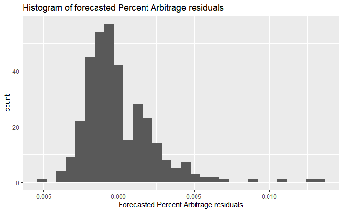

```r
ggplot(arbitrageUSDEUR_forc_bkwdelim, aes(arbitrageUSDEUR_forc_bkwdelim$residuals)) + geom_histogram(bins = 30) +
  ggtitle('Histogram of forecasted Percent Arbitrage residuals') + xlab('Forecasted Percent Arbitrage residuals')
```

- Mean absolute error is 0.1691661%.
- 97.5% of errors are within 0.5475589%.
- Only 3 errors (0.867052% of all errors) are bigger than 1%.
- The model can sometimes forecast a negative value. 2 such forecasts are made for the training set.

Errors plotted by date seem to be somewhat periodical but without excess and are random enough.

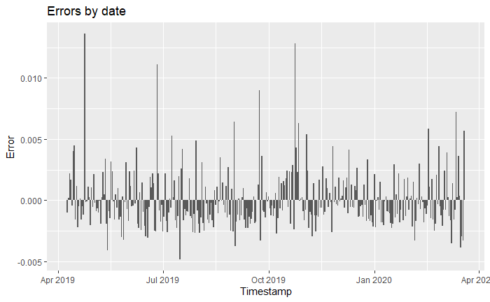

```r
arbitrageUSDEUR_nona %>%
mutate(`Forecasted` = 'Forecasted', `Error` = arbitrageUSDEUR_forc_bkwdelim$residuals) %>%
ggplot(aes(`Timestamp`, `Error`)) + geom_col() + ggtitle('Errors by date')
```

Autocorrelation gives the same picture.

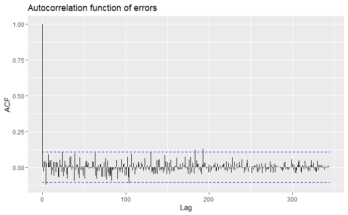

```r
autoplot(acf(arbitrageUSDEUR_forc_bkwdelim$residuals, length(arbitrageUSDEUR_forc_bkwdelim$residuals), plot = FALSE)) +
  ggtitle('Autocorrelation function of errors')
```

The above graphics speak for validity of the model.

### 1.3.4 Forecast summary

> The model has a clear tendency to miss the periods of rapid growth/fall of actual arbitrage and forecasts higher than actual arbitrage in 61.2716763% cases which speaks of the model’s simplification of reality. However the error is acceptably small on training set.

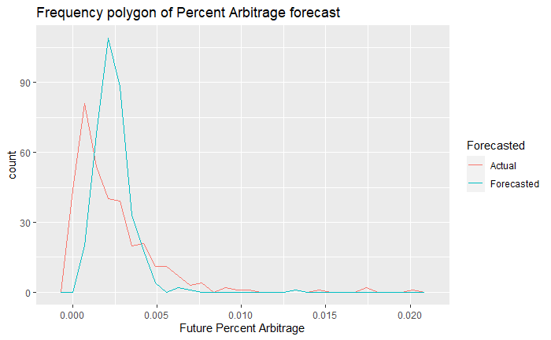

```r
without_negative_predictions <- arbitrageUSDEUR_forc_bkwdelim$fitted.values >= 0
bind_rows(
  arbitrageUSDEUR_nona[without_negative_predictions,] %>%
    mutate(`Forecasted` = 'Actual'),
  arbitrageUSDEUR_nona[without_negative_predictions,] %>%
    mutate(`Forecasted` = 'Forecasted',
           `Future Percent Arbitrage` = arbitrageUSDEUR_forc_bkwdelim$fitted.values[without_negative_predictions])
) %>%
ggplot(aes(`Future Percent Arbitrage`)) + geom_freqpoly(aes(color = `Forecasted`), bins = 30) +
  ggtitle('Frequency polygon of Percent Arbitrage forecast')
```

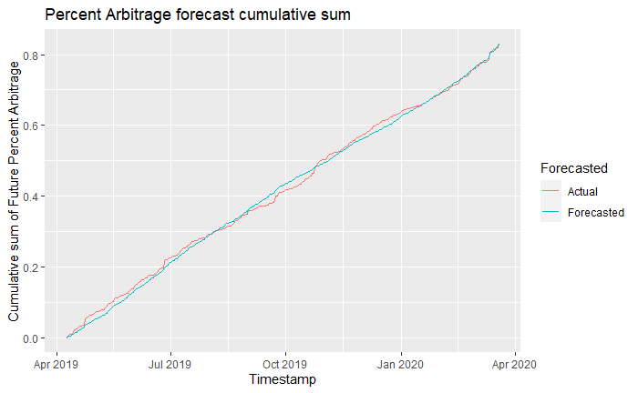

```r
bind_rows(
  arbitrageUSDEUR_nona %>%
    mutate(`Forecasted` = 'Actual', `Cumulative sum of Future Percent Arbitrage` = cumsum(`Future Percent Arbitrage`)),
  arbitrageUSDEUR_nona %>%
    mutate(`Future Percent Arbitrage` = arbitrageUSDEUR_forc_bkwdelim$fitted.values,
           `Forecasted` = 'Forecasted', `Cumulative sum of Future Percent Arbitrage` = cumsum(`Future Percent Arbitrage`))
) %>%
ggplot(aes(`Timestamp`, `Cumulative sum of Future Percent Arbitrage`)) +
  geom_line(aes(color = `Forecasted`)) +
  ggtitle('Percent Arbitrage forecast cumulative sum')
```

### 1.3.5 Simplified model

```r
arbitrageUSDEUR_forc_volume <- lm(as_vector(y) ~ ., X %>% select(`Percent Absolute Return EUR to USD`))
summary(arbitrageUSDEUR_forc_volume)
```

```
Call:
lm(formula = as_vector(y) ~ ., data = X %>% select(`Percent Absolute Return EUR to USD`))

Residuals:
       Min         1Q     Median         3Q        Max
-0.0028409 -0.0016770 -0.0007754  0.0008318  0.0171516

Coefficients:
                                      Estimate Std. Error t value Pr(>|t|)
(Intercept)                          0.0021873  0.0001717  12.740   <2e-16 ***
`Percent Absolute Return EUR to USD` 0.1118872  0.0540994   2.068   0.0394 *
---
Signif. codes:  0 ‘***’ 0.001 ‘**’ 0.01 ‘*’ 0.05 ‘.’ 0.1 ‘ ’ 1

Residual standard error: 0.002585 on 344 degrees of freedom
Multiple R-squared:  0.01228,   Adjusted R-squared:  0.00941
F-statistic: 4.277 on 1 and 344 DF,  p-value: 0.03937
```

#### 1.3.5.1 Error graphics

##### 1.3.5.1.1 Histogram of forecasted Percent Arbitrage residuals

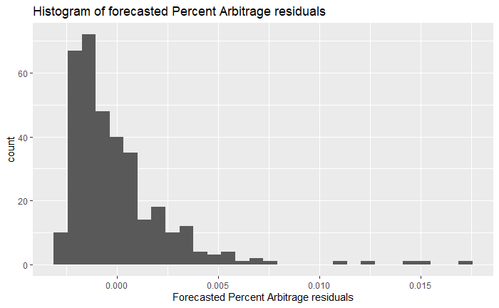

```r
ggplot(arbitrageUSDEUR_forc_volume, aes(arbitrageUSDEUR_forc_volume$residuals)) + geom_histogram(bins = 30) +
  ggtitle('Histogram of forecasted Percent Arbitrage residuals') + xlab('Forecasted Percent Arbitrage residuals')
```

##### 1.3.5.1.2 Errors by date

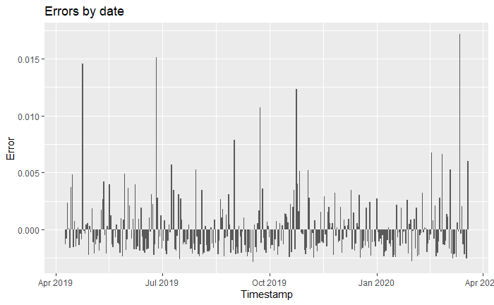

```r
arbitrageUSDEUR_nona %>%
mutate(`Forecasted` = 'Forecasted', `Error` = arbitrageUSDEUR_forc_volume$residuals) %>%
ggplot(aes(`Timestamp`, `Error`)) + geom_col() + ggtitle('Errors by date')
```

##### 1.3.5.1.3 Autocorrelation function of errors

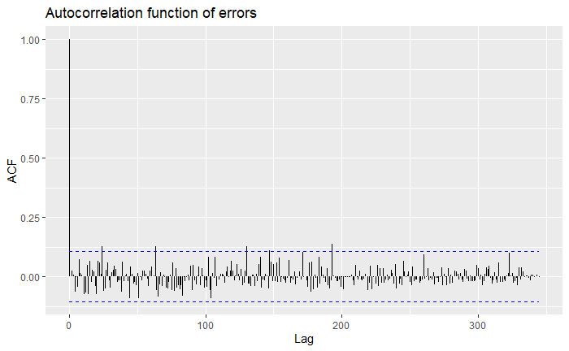

```r
autoplot(acf(arbitrageUSDEUR_forc_volume$residuals, length(arbitrageUSDEUR_forc_volume$residuals), plot = FALSE)) +
  ggtitle('Autocorrelation function of errors')
```

The graphics show that single predictor model is an even more rough estimation. However accuracy is high.

- Mean absolute error is 0.1743024% vs 0.1691661% for the complete model.
- 97.5% of errors are within 0.5830022% vs 0.5475589% for the complete.
- Only 5 errors (1.4450867% of all errors) are bigger than 1% vs 3 errors (0.867052% of all errors) for the complete.

#### 1.3.5.2 Comparison graphics

##### 1.3.5.2.1 Percent Arbitrage forecast frequency polygon

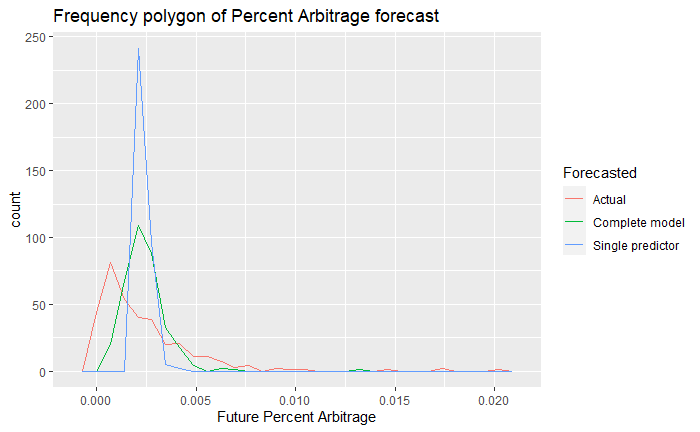

```r
without_negative_predictions <- arbitrageUSDEUR_forc_bkwdelim$fitted.values >= 0
bind_rows(
  arbitrageUSDEUR_nona[without_negative_predictions,] %>%
    mutate(`Forecasted` = 'Actual'),
  arbitrageUSDEUR_nona[without_negative_predictions,] %>%
    mutate(`Forecasted` = 'Complete model',
           `Future Percent Arbitrage` = arbitrageUSDEUR_forc_bkwdelim$fitted.values[without_negative_predictions]),
  arbitrageUSDEUR_nona[without_negative_predictions,] %>%
    mutate(`Forecasted` = 'Single predictor',
           `Future Percent Arbitrage` = arbitrageUSDEUR_forc_volume$fitted.values[without_negative_predictions])
) %>%
ggplot(aes(`Future Percent Arbitrage`)) + geom_freqpoly(aes(color = `Forecasted`), bins = 30) +
  ggtitle('Frequency polygon of Percent Arbitrage forecast')
```

##### 1.3.5.2.2 Percent Arbitrage forecast cumulative sum

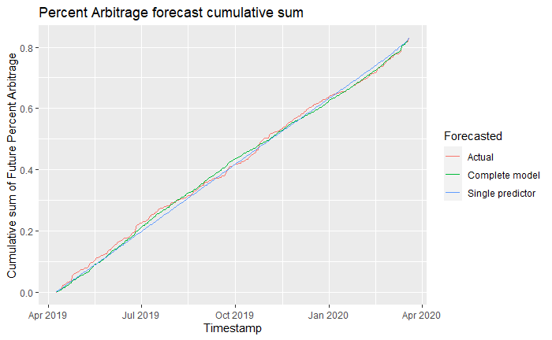

```r
bind_rows(
  arbitrageUSDEUR_nona %>%
    mutate(`Forecasted` = 'Actual', `Cumulative sum of Future Percent Arbitrage` = cumsum(`Future Percent Arbitrage`)),
  arbitrageUSDEUR_nona %>%
    mutate(`Future Percent Arbitrage` = arbitrageUSDEUR_forc_bkwdelim$fitted.values,
           `Forecasted` = 'Complete model', `Cumulative sum of Future Percent Arbitrage` = cumsum(`Future Percent Arbitrage`)),
  arbitrageUSDEUR_nona %>%
    mutate(`Future Percent Arbitrage` = arbitrageUSDEUR_forc_volume$fitted.values,
           `Forecasted` = 'Single predictor', `Cumulative sum of Future Percent Arbitrage` = cumsum(`Future Percent Arbitrage`))
) %>%
ggplot(aes(`Timestamp`, `Cumulative sum of Future Percent Arbitrage`)) +
  geom_line(aes(color = `Forecasted`)) +
  ggtitle('Percent Arbitrage forecast cumulative sum')
```

##### 1.3.5.2.3 Percent Arbitrage forecast cumulative sum complete model

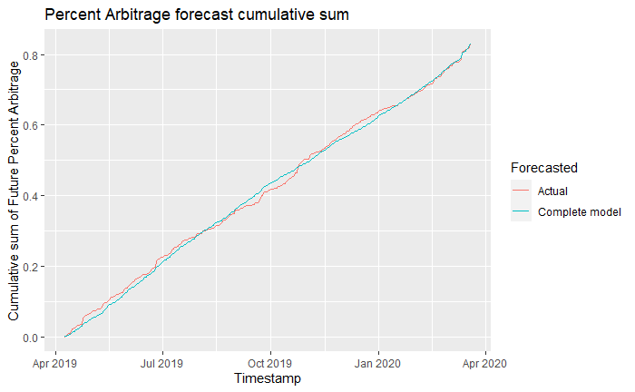

```r
bind_rows(
  arbitrageUSDEUR_nona %>%
    mutate(`Forecasted` = 'Actual', `Cumulative sum of Future Percent Arbitrage` = cumsum(`Future Percent Arbitrage`)),
  arbitrageUSDEUR_nona %>%
    mutate(`Future Percent Arbitrage` = arbitrageUSDEUR_forc_bkwdelim$fitted.values,
           `Forecasted` = 'Complete model', `Cumulative sum of Future Percent Arbitrage` = cumsum(`Future Percent Arbitrage`))
) %>%
ggplot(aes(`Timestamp`, `Cumulative sum of Future Percent Arbitrage`)) +
  geom_line(aes(color = `Forecasted`)) +
  ggtitle('Percent Arbitrage forecast cumulative sum')
```

##### 1.3.5.2.4 Percent Arbitrage forecast cumulative sum single predictor

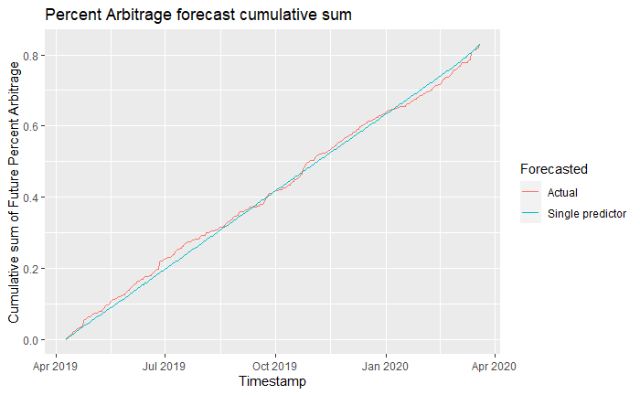

```r
bind_rows(
  arbitrageUSDEUR_nona %>%
    mutate(`Forecasted` = 'Actual', `Cumulative sum of Future Percent Arbitrage` = cumsum(`Future Percent Arbitrage`)),
  arbitrageUSDEUR_nona %>%
    mutate(`Future Percent Arbitrage` = arbitrageUSDEUR_forc_volume$fitted.values,
           `Forecasted` = 'Single predictor', `Cumulative sum of Future Percent Arbitrage` = cumsum(`Future Percent Arbitrage`))
) %>%
ggplot(aes(`Timestamp`, `Cumulative sum of Future Percent Arbitrage`)) +
  geom_line(aes(color = `Forecasted`)) +
  ggtitle('Percent Arbitrage forecast cumulative sum')
```

### 1.3.6 Random forest model

A random forest forecasting future perent arbitrage reaveals feature importance using permuatition strategy to calculate importances.

```r
arbitrageUSDEUR_forc_rf <- ranger(x = X, y = as_vector(y), num.trees = 1000, max.depth = 7, importance = 'permutation', seed = 0)
arbitrageUSDEUR_forc_rf$fitted.values <- arbitrageUSDEUR_forc_rf$predictions
arbitrageUSDEUR_forc_rf$residuals <- as_vector(y) - arbitrageUSDEUR_forc_rf$fitted.values
arbitrageUSDEUR_forc_rf
```

```
Ranger result

Call:
 ranger(x = X, y = as_vector(y), num.trees = 1000, max.depth = 7,      importance = "permutation", seed = 0)

Type:                             Regression
Number of trees:                  1000
Sample size:                      346
Number of independent variables:  32
Mtry:                             5
Target node size:                 5
Variable importance mode:         permutation
Splitrule:                        variance
OOB prediction error (MSE):       7.047264e-06
R squared (OOB):                  -0.04472983
```

#### 1.3.6.1 Error graphics

##### 1.3.6.1.1 Histogram of forecasted Percent Arbitrage residuals

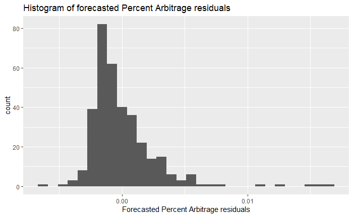

```r
ggplot(arbitrageUSDEUR_nona, aes(arbitrageUSDEUR_forc_rf$residuals)) + geom_histogram(bins = 30) +
  ggtitle('Histogram of forecasted Percent Arbitrage residuals') + xlab('Forecasted Percent Arbitrage residuals')
```

##### 1.3.6.1.2 Errors by date

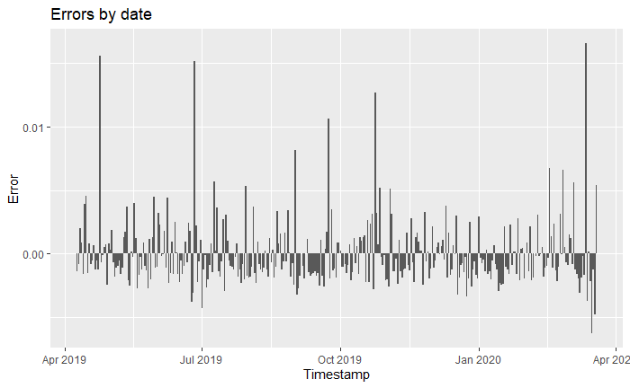

```r
arbitrageUSDEUR_nona %>%
mutate(`Forecasted` = 'Forecasted', `Error` = arbitrageUSDEUR_forc_rf$residuals) %>%
ggplot(aes(`Timestamp`, `Error`)) + geom_col() + ggtitle('Errors by date')
```

##### 1.3.6.1.3 Autocorrelation function of errors

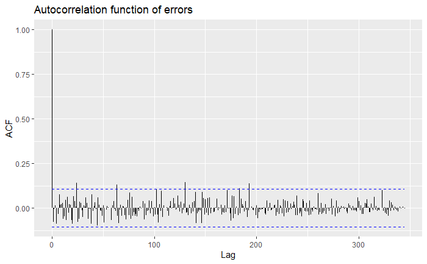

```r
autoplot(acf(arbitrageUSDEUR_forc_rf$residuals, length(arbitrageUSDEUR_forc_rf$residuals), plot = FALSE)) +
  ggtitle('Autocorrelation function of errors')
```

#### 1.3.6.2 Comparison graphics

##### 1.3.6.2.1 Percent Arbitrage forecast frequency polygon

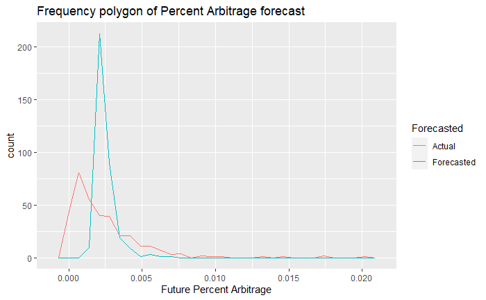

```r
without_negative_predictions <- arbitrageUSDEUR_forc_rf$fitted.values >= 0
bind_rows(
  arbitrageUSDEUR_nona[without_negative_predictions,] %>%
    mutate(`Forecasted` = 'Actual'),
  arbitrageUSDEUR_nona[without_negative_predictions,] %>%
    mutate(`Forecasted` = 'Forecasted',
           `Future Percent Arbitrage` = arbitrageUSDEUR_forc_rf$fitted.values[without_negative_predictions])
) %>%
ggplot(aes(`Future Percent Arbitrage`)) + geom_freqpoly(aes(color = `Forecasted`), bins = 30) +
  ggtitle('Frequency polygon of Percent Arbitrage forecast')
```

##### 1.3.6.2.2 Percent Arbitrage forecast cumulative sum

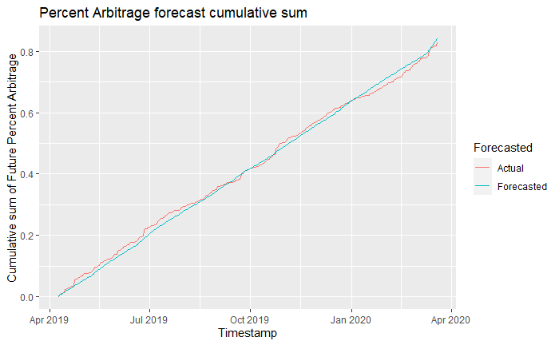

```r
bind_rows(
  arbitrageUSDEUR_nona %>%
    mutate(`Forecasted` = 'Actual', `Cumulative sum of Future Percent Arbitrage` = cumsum(`Future Percent Arbitrage`)),
  arbitrageUSDEUR_nona %>%
    mutate(`Future Percent Arbitrage` = arbitrageUSDEUR_forc_rf$fitted.values,
           `Forecasted` = 'Forecasted', `Cumulative sum of Future Percent Arbitrage` = cumsum(`Future Percent Arbitrage`))
) %>%
ggplot(aes(`Timestamp`, `Cumulative sum of Future Percent Arbitrage`)) +
  geom_line(aes(color = `Forecasted`)) +
  ggtitle('Percent Arbitrage forecast cumulative sum')
```

The result is generally similar to linear model’s and supports the idea of correlation between EUR to USD rates and VIX and future percent arbitrage.

```r
rf_feature_importances <- sort(arbitrageUSDEUR_forc_rf$variable.importance /
                                 sum(arbitrageUSDEUR_forc_rf$variable.importance), decreasing = TRUE)
tibble(
 feature = names(rf_feature_importances),
 importance = rf_feature_importances
)
```

| feature | importance |
| --- | --- |
| Percent Return EUR to USD | 1.095298e-01 |
| SD Percent Return VIX | 7.902557e-02 |
| Percent Absolute Return EUR to USD | 6.559823e-02 |
| SD Percent Absolute Return EUR to USD | 6.322785e-02 |
| Percent Open VIX | 6.088748e-02 |
| SD Percent Return EUR to USD | 5.269252e-02 |
| Percent Return EUR in USD | 4.625783e-02 |
| Percent Low VIX | 4.608829e-02 |
| Percent Close VIX | 4.588528e-02 |
| Percent Volume Change EUR in USD | 4.261490e-02 |

[output cut: 22 more lines]

### 1.3.7 Linear model forecasting price ratios

A close to normal distribution to use as target for prediction can be achieved by dividing weighted price of bitcoin in USD by it’s weighted price in EUR converted to USD:
$$USD\ EUR\ in\ USD\ price\ ratio = \frac{Weighted\ Price\ USD}{Weighted\ Price\ EUR\ in\ USD}$$

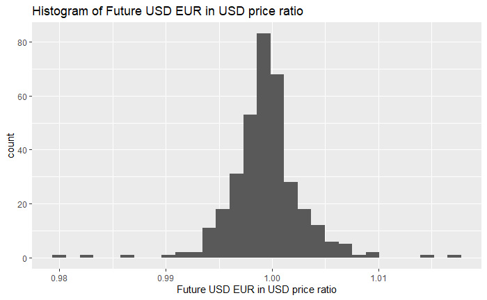

```r
ggplot(arbitrageUSDEUR_nona, aes(`Future USD EUR in USD price ratio`)) + geom_histogram(bins = 30) +
  ggtitle('Histogram of Future USD EUR in USD price ratio')
```

```r
(arbitrageUSDEUR_nona %>%
  select(`Future USD EUR in USD price ratio`) %>%
  filter(between(`Future USD EUR in USD price ratio`,
                 quantile(`Future USD EUR in USD price ratio`, 0.025),
                 quantile(`Future USD EUR in USD price ratio`, 0.975)))
)$`Future USD EUR in USD price ratio` %>%
  shapiro.test()
```

```
    Shapiro-Wilk normality test

data:  .
W = 0.98926, p-value = 0.01622
```

Next these values are substracted from 1 and take into absolute to get the percent arbitrage:
$$Percent\ Arbitrage = |1 - USD\ EUR\ in\ USD\ price\ ratio|$$

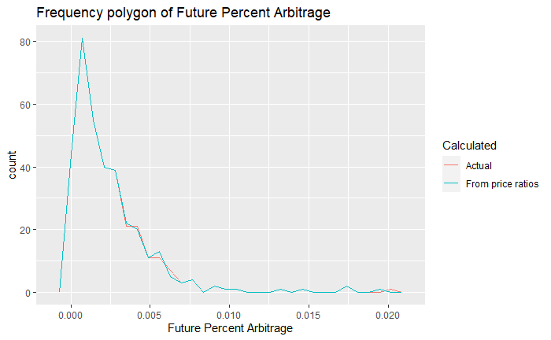

```r
bind_rows(
  arbitrageUSDEUR_nona %>%
    mutate(`Calculated` = 'Actual'),
  arbitrageUSDEUR_nona %>%
    mutate(`Calculated` = 'From price ratios',
           `Future Percent Arbitrage` = abs(1 - `Future USD EUR in USD price ratio`))
) %>%
ggplot(aes(`Future Percent Arbitrage`)) + geom_freqpoly(aes(color = `Calculated`), bins = 30) +
  ggtitle('Frequency polygon of Future Percent Arbitrage')
```

A linear model is trained using all available predictors and passes a backward feature elimination algorithm.

```r
arbitrageUSDEUR_forc_ratio <- stepAIC(lm(arbitrageUSDEUR_nona$`Future USD EUR in USD price ratio` ~ ., X),
                                      direction = 'both', trace = FALSE)
summary(arbitrageUSDEUR_forc_bkwdelim)
```

```
Call:
lm(formula = as_vector(y) ~ `Percent Close VIX` + `Percent High VIX` +
    `Percent Close Hype` + `Percent Return USD` + `Percent Return EUR in USD` +
    `Percent Return EUR to USD` + `Percent Return GSPC` + `Percent Return DJI` +
    `Percent Volume Change EUR in USD` + `Percent Volume Change DJI` +
    `SD Percent Return USD` + `SD Percent Return EUR in USD` +
    `SD Percent Return GSPC` + `SD Percent Return Hype` + `SD Percent Volume Change EUR to USD`,
    data = X)

Residuals:
       Min         1Q     Median         3Q        Max
-0.0048325 -0.0014994 -0.0005322  0.0011238  0.0136056

Coefficients:
                                        Estimate Std. Error t value Pr(>|t|)
(Intercept)                           -9.981e-04  8.002e-04  -1.247 0.213190
`Percent Close VIX`                    4.603e-04  1.207e-04   3.814 0.000163 ***
`Percent High VIX`                    -2.556e-04  9.494e-05  -2.692 0.007467 **
`Percent Close Hype`                   2.506e-05  1.649e-05   1.520 0.129562
`Percent Return USD`                   8.786e-02  5.192e-02   1.692 0.091508 .
`Percent Return EUR in USD`           -9.746e-02  5.290e-02  -1.842 0.066319 .
`Percent Return EUR to USD`           -1.512e-01  4.597e-02  -3.290 0.001111 **
`Percent Return GSPC`                 -1.205e-01  6.766e-02  -1.781 0.075802 .
`Percent Return DJI`                   1.439e-01  6.599e-02   2.181 0.029893 *
`Percent Volume Change EUR in USD`     4.674e-04  1.941e-04   2.408 0.016568 *
`Percent Volume Change DJI`           -3.331e-04  2.368e-04  -1.407 0.160373
`SD Percent Return USD`                2.010e-01  9.877e-02   2.035 0.042634 *
`SD Percent Return EUR in USD`        -2.108e-01  1.027e-01  -2.053 0.040845 *
`SD Percent Return GSPC`              -1.080e-01  4.905e-02  -2.201 0.028420 *
`SD Percent Return Hype`              -9.218e-05  6.391e-05  -1.442 0.150159
`SD Percent Volume Change EUR to USD`  1.573e-03  9.851e-04   1.597 0.111315
---
Signif. codes:  0 ‘***’ 0.001 ‘**’ 0.01 ‘*’ 0.05 ‘.’ 0.1 ‘ ’ 1

Residual standard error: 0.002402 on 330 degrees of freedom
Multiple R-squared:  0.1818,    Adjusted R-squared:  0.1446
F-statistic: 4.888 on 15 and 330 DF,  p-value: 1.246e-08
```

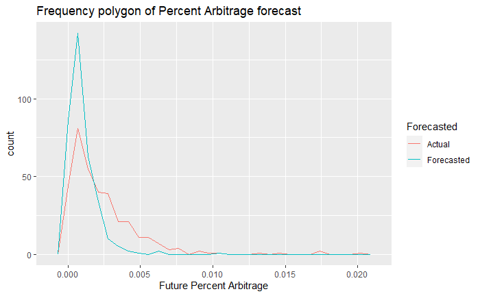

```r
bind_rows(
  arbitrageUSDEUR_nona %>%
    mutate(`Forecasted` = 'Actual'),
  arbitrageUSDEUR_nona %>%
    mutate(`Forecasted` = 'Forecasted',
           `Future Percent Arbitrage` = abs(1 - arbitrageUSDEUR_forc_ratio$fitted.values))
) %>%
ggplot(aes(`Future Percent Arbitrage`)) + geom_freqpoly(aes(color = `Forecasted`), bins = 30) +
  ggtitle('Frequency polygon of Percent Arbitrage forecast')
```

In time it leads to a huge gap between forecasted and real accumulated arbitrage.

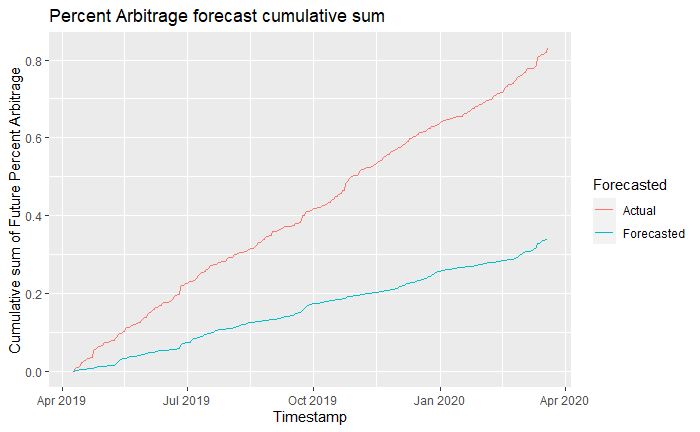

```r
bind_rows(
  arbitrageUSDEUR_nona %>%
    mutate(`Forecasted` = 'Actual', `Cumulative sum of Future Percent Arbitrage` = cumsum(`Future Percent Arbitrage`)),
  arbitrageUSDEUR_nona %>%
    mutate(`Future Percent Arbitrage` = abs(1 - arbitrageUSDEUR_forc_ratio$fitted.values),
           `Forecasted` = 'Forecasted', `Cumulative sum of Future Percent Arbitrage` = cumsum(`Future Percent Arbitrage`))
) %>%
ggplot(aes(`Timestamp`, `Cumulative sum of Future Percent Arbitrage`)) +
  geom_line(aes(color = `Forecasted`)) +
  ggtitle('Percent Arbitrage forecast cumulative sum')
```

### 1.3.8 Random forest model forecasting percent return

A random forest forecasting future percent return reaveals feature importance using permuatition strategy to calculate importances.

```r
arbitrageUSDEUR_forc_rf <- ranger(x = X, y = arbitrageUSDEUR_nona$`Future Percent Return USD`,
                                  num.trees = 1000, max.depth = 7, importance = 'permutation', seed = 0)
arbitrageUSDEUR_forc_rf$fitted.values <- arbitrageUSDEUR_forc_rf$predictions
arbitrageUSDEUR_forc_rf$residuals <- as_vector(y) - arbitrageUSDEUR_forc_rf$fitted.values
arbitrageUSDEUR_forc_rf
```

```
Ranger result

Call:
 ranger(x = X, y = arbitrageUSDEUR_nona$`Future Percent Return USD`,      num.trees = 1000, max.depth = 7, importance = "permutation",      seed = 0)

Type:                             Regression
Number of trees:                  1000
Sample size:                      346
Number of independent variables:  32
Mtry:                             5
Target node size:                 5
Variable importance mode:         permutation
Splitrule:                        variance
OOB prediction error (MSE):       0.002185474
R squared (OOB):                  -0.1040659
```

#### 1.3.8.1 Error graphics

##### 1.3.8.1.1 Histogram of forecasted Percent Return residuals

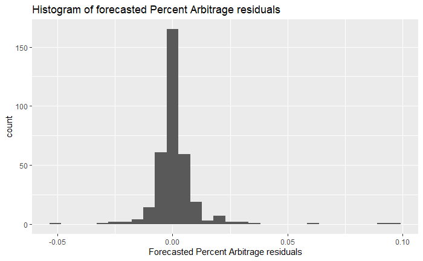

```r
ggplot(arbitrageUSDEUR_nona, aes(arbitrageUSDEUR_forc_rf$residuals)) + geom_histogram(bins = 30) +
  ggtitle('Histogram of forecasted Percent Arbitrage residuals') + xlab('Forecasted Percent Arbitrage residuals')
```

##### 1.3.8.1.2 Errors by date

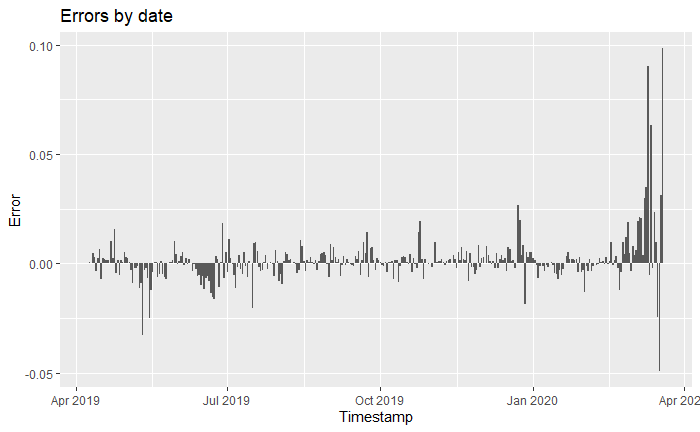

```r
arbitrageUSDEUR_nona %>%
mutate(`Forecasted` = 'Forecasted', `Error` = arbitrageUSDEUR_forc_rf$residuals) %>%
ggplot(aes(`Timestamp`, `Error`)) + geom_col() + ggtitle('Errors by date')
```

##### 1.3.8.1.3 Autocorrelation function of errors

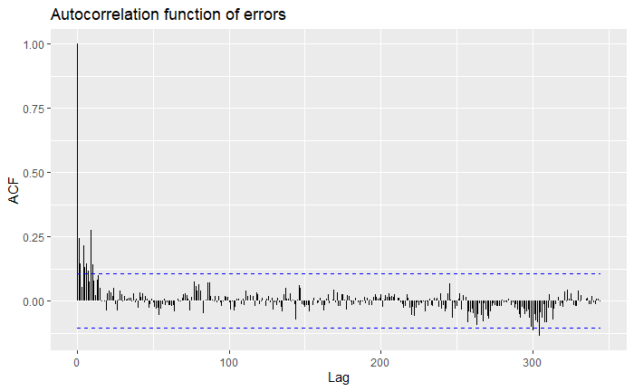

```r
autoplot(acf(arbitrageUSDEUR_forc_rf$residuals, length(arbitrageUSDEUR_forc_rf$residuals), plot = FALSE)) +
  ggtitle('Autocorrelation function of errors')
```

- Mean absolute error is 2.1144749
- 97.5% of errors are within 3.7612578%.
- Only 169 errors (48.8439306% of all errors) are bigger than 1%.

#### 1.3.8.2 Comparison graphics

##### 1.3.8.2.1 Percent Return forecast frequency polygon

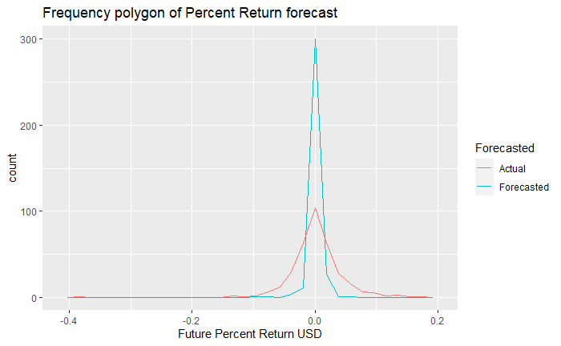

```r
bind_rows(
  arbitrageUSDEUR_nona %>%
    mutate(`Forecasted` = 'Actual'),
  arbitrageUSDEUR_nona %>%
    mutate(`Forecasted` = 'Forecasted',
           `Future Percent Return USD` = arbitrageUSDEUR_forc_rf$fitted.values)
) %>%
ggplot(aes(`Future Percent Return USD`)) + geom_freqpoly(aes(color = `Forecasted`), bins = 30) +
  ggtitle('Frequency polygon of Percent Return forecast')
```

##### 1.3.8.2.2 Percent Return forecast cumulative sum

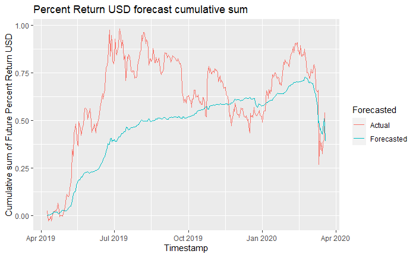

```r
bind_rows(
  arbitrageUSDEUR_nona %>%
    mutate(`Forecasted` = 'Actual', `Cumulative sum of Future Percent Return USD` = cumsum(`Future Percent Return USD`)),
  arbitrageUSDEUR_nona %>%
    mutate(`Future Percent Return USD` = arbitrageUSDEUR_forc_rf$fitted.values,
           `Forecasted` = 'Forecasted', `Cumulative sum of Future Percent Return USD` = cumsum(`Future Percent Return USD`))
) %>%
ggplot(aes(`Timestamp`, `Cumulative sum of Future Percent Return USD`)) +
  geom_line(aes(color = `Forecasted`)) +
  ggtitle('Percent Return USD forecast cumulative sum')
```

### 1.3.9 Feature importances

```r
rf_feature_importances <- sort(arbitrageUSDEUR_forc_rf$variable.importance /
                                 sum(arbitrageUSDEUR_forc_rf$variable.importance), decreasing = TRUE)
tibble(
 feature = names(rf_feature_importances),
 importance = rf_feature_importances
)
```

| feature | importance |
| --- | --- |
| Percent Low VIX | 0.125782665 |
| SD Percent Return GSPC | 0.113167539 |
| Percent Close VIX | 0.082782678 |
| Percent Open VIX | 0.068126023 |
| SD Percent Volume Change DJI | 0.062748406 |
| SD Percent Return DJI | 0.062409891 |
| SD Percent Volume Change EUR in USD | 0.055411725 |
| SD Percent Return USD | 0.052700502 |
| Percent Return USD | 0.049828094 |
| SD Percent Return VIX | 0.049040795 |

[output cut: 22 more lines]

### 1.3.10 Decision tree model forecasting percent return

A decision tree can be used for mining feature importances. However it’s decisions should be taken with a grain of salt considering it’s nature: to split the training sample without consideration of the feature’s real value while lacking the natural defence mechanism of random forest (the “parliament” principle).

```r
arbitrageUSDEUR_forc_rf <- rpart(arbitrageUSDEUR_nona$`Future Percent Return USD` ~ ., data = X,
                                 control = rpart.control(minsplit = 2, minbucket = 1))
arbitrageUSDEUR_forc_rf$fitted.values <- predict(arbitrageUSDEUR_forc_rf, newdata = X)
arbitrageUSDEUR_forc_rf$residuals <- as_vector(y) - arbitrageUSDEUR_forc_rf$fitted.values
arbitrageUSDEUR_forc_rf
```

[output not shown]

#### 1.3.10.1 Error graphics

##### 1.3.10.1.1 Histogram of forecasted Percent Return residuals

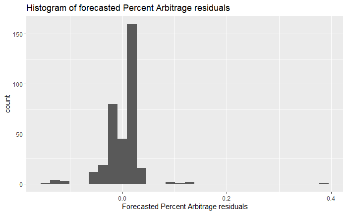

```r
ggplot(arbitrageUSDEUR_nona, aes(arbitrageUSDEUR_forc_rf$residuals)) + geom_histogram(bins = 30) +
  ggtitle('Histogram of forecasted Percent Arbitrage residuals') + xlab('Forecasted Percent Arbitrage residuals')
```